# Customer Data Analytics

### Analyzed by: Nitish Bhardwaj

```python
#Import all the required libraries
#Graphical Libraries
import plotly.graph_objects as go
from plotly.subplots import make_subplots
import matplotlib.pyplot as plt

#Data manipulation
import pandas as pd
import numpy as np
import datetime as dt

#To access index from list of list values
import functools
import operator
```

Import the data file

```python
xls = pd.ExcelFile('data.xlsx')
#import data from different tabs of excel
dfCustomerSeg = pd.read_excel(xls, 'Customer Segments')
dfBillStatus = pd.read_excel(xls, 'Billing Status')
print("Shape of dfCustomerSeg: ",dfCustomerSeg.shape)
print("Shape of dfBillStatus: ",dfBillStatus.shape)
```

```
Shape of dfCustomerSeg:  (1000, 6)
Shape of dfBillStatus:  (1000, 5)
```

```python
print("Customer Segmentation Data")
dfCustomerSeg.head()
```

```
Customer Segmentation Data
```

|  | Customer ID | Free Account Created Date | Last Seen | Session Count | Segment | Billing Account # |
| --- | --- | --- | --- | --- | --- | --- |
| 0 | 1 | 2017-05-29 | 2019-04-05 08:02:32 | 1379 | Marketing Segment 2 | AX#93195 |
| 1 | 2 | 2017-12-17 | 2019-04-27 13:23:56 | 531 | Marketing Segment 1 | AX#20438 |
| 2 | 3 | 2017-01-30 | 2019-04-22 15:38:09 | 317 | Marketing Segment 1 | AX#60779 |
| 3 | 4 | 2017-02-03 | 2019-04-23 16:30:46 | 349 | Marketing Segment 1 | AX#91209 |
| 4 | 5 | 2017-03-18 | 2019-04-05 13:16:33 | 1158 | Marketing Segment 2 | AX#57000 |

```python
print("Billing Status Data")
dfBillStatus.head()
```

```
Billing Status Data
```

|  | Billing Account # | Account Status | Upgraded Account Created Date | Upgraded Account Cancelled Date | Total Charges |
| --- | --- | --- | --- | --- | --- |
| 0 | AX#10042 | paying | 2019-03-20 | NaT | 332.800000 |
| 1 | AX#10114 | paying | 2019-01-17 | NaT | 451.133333 |
| 2 | AX#10259 | paying | 2018-09-28 | NaT | 1886.800000 |
| 3 | AX#10695 | paying | 2018-12-21 | NaT | 797.866667 |
| 4 | AX#10855 | paying | 2019-04-01 | NaT | 189.000000 |

Merge the Customer Segments data with Billing Status data based on "Billing Account #"

```python
df = dfCustomerSeg.join(dfBillStatus.set_index('Billing Account #'), on='Billing Account #', how='left')
df.columns
print("Shape of dataframe having details of Customer Segments and Billing Status:", df.shape)
```

```
Shape of dataframe having details of Customer Segments and Billing Status: (1014, 10)
```

```python
#View the details of Customer Segments and Billing Status
df.info()
```

```
<class 'pandas.core.frame.DataFrame'>
Int64Index: 1014 entries, 0 to 999
Data columns (total 10 columns):
 #   Column                           Non-Null Count  Dtype
---  ------                           --------------  -----
 0   Customer ID                      1014 non-null   int64
 1   Free Account Created Date        1014 non-null   datetime64[ns]
 2   Last Seen                        1014 non-null   datetime64[ns]
 3   Session Count                    1014 non-null   int64
 4   Segment                          1014 non-null   object
 5   Billing Account #                1014 non-null   object
 6   Account Status                   1014 non-null   object
 7   Upgraded Account Created Date    1014 non-null   datetime64[ns]
 8   Upgraded Account Cancelled Date  123 non-null    datetime64[ns]
 9   Total Charges                    1014 non-null   float64
dtypes: datetime64[ns](4), float64(1), int64(2), object(3)
memory usage: 87.1+ KB
```

```python
print("The dataset contains data only for:", df['Last Seen'].dt.year.nunique(), "year(s) i.e."
     ,*df['Last Seen'].dt.year.unique())
```

```
The dataset contains data only for: 3 year(s) i.e. 2019 2017 2018
```

```python
#Check if any values are missing:
df.isna().sum()
```

```
Customer ID                          0
Free Account Created Date            0
Last Seen                            0
Session Count                        0
Segment                              0
Billing Account #                    0
Account Status                       0
Upgraded Account Created Date        0
Upgraded Account Cancelled Date    891
Total Charges                        0
dtype: int64
```

Note:

1. No missing values found except "Upgraded Account Cancelled Date".
2. "Upgraded Account Cancelled Date" are having missing values as not every customer has churned. However, it needs to be further investigated.

Verify that no Account Cancellation date is missing if the Account Status is Cancelled.

```python
df[df['Account Status']=='cancelled']['Upgraded Account Cancelled Date'].isna().sum()
```

```
2
```

Note:

```
1. It is found that two Account Cancellation dates are missing even if the Account Status is Cancelled. This needs to be fixed.
```

```python
#Print the details of account that are cancelled but have not cancellation date.
df[(df['Account Status']=='cancelled')&(df['Upgraded Account Cancelled Date'].isna())]
```

|  | Customer ID | Free Account Created Date | Last Seen | Session Count | Segment | Billing Account # | Account Status | Upgraded Account Created Date | Upgraded Account Cancelled Date | Total Charges |
| --- | --- | --- | --- | --- | --- | --- | --- | --- | --- | --- |
| 321 | 322 | 2018-10-05 | 2019-04-26 19:45:48 | 1 | Marketing Segment 2 | AX#12986 | cancelled | 2019-04-21 | NaT | 33.833333 |
| 813 | 814 | 2019-03-23 | 2019-04-23 07:13:37 | 9 | Marketing Segment 1 | AX#21943 | cancelled | 2019-04-15 | NaT | 126.966667 |

Note: It can be noticed that both the a/c are active after around 10 days of upgrading the account. It could be a data entry error. However, if the account is really cancelled then by considering them active we may exclude them from our future scheme to bring the customers back. So let's assume that the two accounts are cancelled and replace their cancellation date with Last Seen date as it is within 10 days duration from the upgrade date.

```python
df.loc[(df['Account Status']=='cancelled')&(df['Upgraded Account Cancelled Date'].isna()),
       'Upgraded Account Cancelled Date'] = df.loc[
    (df['Account Status']=='cancelled')& (df['Upgraded Account Cancelled Date'].isna()),
       'Last Seen'].dt.date
```

Verify if both the rows have got the last seen date

```python
#Print the details of account that are cancelled but have not cancellation date.
df[(df['Account Status']=='cancelled')&(df['Upgraded Account Cancelled Date'].isna())]
```

|  | Customer ID | Free Account Created Date | Last Seen | Session Count | Segment | Billing Account # | Account Status | Upgraded Account Created Date | Upgraded Account Cancelled Date | Total Charges |
| --- | --- | --- | --- | --- | --- | --- | --- | --- | --- | --- |

Check the number of unique values in dataset

```python
#Check the unique values:
df.nunique()
```

```
Customer ID                        1000
Free Account Created Date           402
Last Seen                           996
Session Count                       257
Segment                               3
Billing Account #                   993
Account Status                        2
Upgraded Account Created Date       313
Upgraded Account Cancelled Date      97
Total Charges                       962
dtype: int64
```

Note:

1. There are 1000 unique customer id's as opposed to 993 unique Billing Account #.
2. There are 3 customer segments present in the dataset.

## Custom RFM Analysis

RFM (Recency, Frequency, Monetary) analysis is a customer segmentation technique that uses past purchase behavior to divide customers into groups. RFM helps divide customers into various categories or clusters to identify customers who are more likely to respond to promotions and also for future personalization services.

RECENCY (R): Days since last seen

FREQUENCY (F): Total Session Count

MONETARY VALUE (M): Total money customer spent i.e. Total Charges

```python
df.head()
```

|  | Customer ID | Free Account Created Date | Last Seen | Session Count | Segment | Billing Account # | Account Status | Upgraded Account Created Date | Upgraded Account Cancelled Date | Total Charges |
| --- | --- | --- | --- | --- | --- | --- | --- | --- | --- | --- |
| 0 | 1 | 2017-05-29 | 2019-04-05 08:02:32 | 1379 | Marketing Segment 2 | AX#93195 | paying | 2019-04-02 | NaT | 145.600000 |
| 1 | 2 | 2017-12-17 | 2019-04-27 13:23:56 | 531 | Marketing Segment 1 | AX#20438 | paying | 2018-11-11 | NaT | 728.000000 |
| 2 | 3 | 2017-01-30 | 2019-04-22 15:38:09 | 317 | Marketing Segment 1 | AX#60779 | paying | 2019-03-15 | NaT | 277.200000 |
| 3 | 4 | 2017-02-03 | 2019-04-23 16:30:46 | 349 | Marketing Segment 1 | AX#91209 | paying | 2019-03-24 | NaT | 292.833333 |
| 4 | 5 | 2017-03-18 | 2019-04-05 13:16:33 | 1158 | Marketing Segment 2 | AX#57000 | paying | 2018-10-12 | NaT | 462.000000 |

### Processing Recency

```python
#last seen date
print("The last transaction date in the dataset:", df['Last Seen'].max())
```

```
The last transaction date in the dataset: 2019-04-28 20:56:17
```

```python
#Store value of maximum last seen date into 'now' variable for easier reference
now = dt.date(df['Last Seen'].dt.date.max().year, #Maximum Year from dataset
              df['Last Seen'].dt.date.max().month, # Maximum Month from dataset
              df['Last Seen'].dt.date.max().day) # Maximum Date from dataset
print('Current Date:',now)
```

```
Current Date: 2019-04-28
```

```python
#create a new column having only date of last seen i.e. date without time
df['Last_Seen_RFM'] = pd.DatetimeIndex(df['Last Seen']).date
```

```python
#group by customers and populate last seen date
recency_df = df.groupby(by='Customer ID', as_index=False)['Last_Seen_RFM'].max()
recency_df.columns = ['CustomerID','LastSeenDate']
recency_df.head()
```

|  | CustomerID | LastSeenDate |
| --- | --- | --- |
| 0 | 1 | 2019-04-05 |
| 1 | 2 | 2019-04-27 |
| 2 | 3 | 2019-04-22 |
| 3 | 4 | 2019-04-23 |
| 4 | 5 | 2019-04-05 |

```python
#calculate recency
recency_df['Recency'] = recency_df['LastSeenDate'].apply(lambda x: (now - x).days)
#drop LastTransactionDate as recency is computed
recency_df.drop('LastSeenDate',axis=1,inplace=True)
print("Data processed for Recency")
recency_df.head()
```

```
Data processed for Recency
```

|  | CustomerID | Recency |
| --- | --- | --- |
| 0 | 1 | 23 |
| 1 | 2 | 1 |
| 2 | 3 | 6 |
| 3 | 4 | 5 |
| 4 | 5 | 23 |

### Processing Frequency

We can consider Session count as frequency of customer interaction to the system

```python
#Renaming Session count to Frequency
frequency_df = df[['Customer ID','Session Count']].copy()
frequency_df.rename(columns={"Customer ID":"CustomerID","Session Count": "Frequency"}, inplace=True)
frequency_df.head()
```

|  | CustomerID | Frequency |
| --- | --- | --- |
| 0 | 1 | 1379 |
| 1 | 2 | 531 |
| 2 | 3 | 317 |
| 3 | 4 | 349 |
| 4 | 5 | 1158 |

### Processing Monetary

```python
#Copy Total Charges from main dataframe to monetary_df dataframe
monetary_df = df[['Customer ID','Total Charges']].copy()
#Rename the columns for future reference of Monetary
monetary_df.rename(columns={"Customer ID":"CustomerID","Total Charges": "Monetary"}, inplace=True)
#Add the total monetary of same customers
monetary_df = monetary_df.groupby(by='CustomerID',as_index=False).agg({'Monetary': 'sum'})
#Round the values of Monetary to two digits after decimal
monetary_df['Monetary'] = monetary_df['Monetary'].round(2)
monetary_df.head()
```

|  | CustomerID | Monetary |
| --- | --- | --- |
| 0 | 1 | 145.60 |
| 1 | 2 | 728.00 |
| 2 | 3 | 277.20 |
| 3 | 4 | 292.83 |
| 4 | 5 | 462.00 |

Create a RFM Table having all the three columns with customerId as index

```python
#merge recency dataframe with frequency dataframe
temp_df = recency_df.merge(frequency_df,on='CustomerID')
#merge with monetary dataframe to get a table with the 3 columns
rfm_df = temp_df.merge(monetary_df,on='CustomerID')
#use customerId as index
rfm_df.set_index('CustomerID',inplace=True)
#check the head
rfm_df.head()
```

| CustomerID | Recency | Frequency | Monetary |
| --- | --- | --- | --- |
| 1 | 23 | 1379 | 145.60 |
| 2 | 1 | 531 | 728.00 |
| 3 | 6 | 317 | 277.20 |
| 4 | 5 | 349 | 292.83 |
| 5 | 23 | 1158 | 462.00 |

### RFM Table Validation

```python
#Assign a customer id from the RFM table to verify the data
cust_id_valid = 3
df[df['Customer ID']==cust_id_valid]
```

|  | Customer ID | Free Account Created Date | Last Seen | Session Count | Segment | Billing Account # | Account Status | Upgraded Account Created Date | Upgraded Account Cancelled Date | Total Charges | Last_Seen_RFM |
| --- | --- | --- | --- | --- | --- | --- | --- | --- | --- | --- | --- |
| 2 | 3 | 2017-01-30 | 2019-04-22 15:38:09 | 317 | Marketing Segment 1 | AX#60779 | paying | 2019-03-15 | NaT | 277.2 | 2019-04-22 |

```python
#Recency Test
print("Recency values between RFM table and origional table matched?:  ",
      (now - (df[df['Customer ID']==cust_id_valid]
             ['Last Seen'].dt.date.max())).days== rfm_df[rfm_df.index==cust_id_valid]['Recency'].values[0])

#Frequency Test
print("\nFrequency values between RFM table and origional table matched?: ",
      df[df['Customer ID']==cust_id_valid]
      ['Session Count'].values[0]==rfm_df[rfm_df.index==cust_id_valid]['Frequency'].values[0])

#Monetary Test
print("\nMonetary values between RFM table and origional table matched?: ",
      df[df['Customer ID']==cust_id_valid]
      ['Total Charges'].sum() == rfm_df[rfm_df.index==cust_id_valid]['Monetary'].values[0])
```

```
Recency values between RFM table and origional table matched?:   True

Frequency values between RFM table and origional table matched?:  True

Monetary values between RFM table and origional table matched?:  True
```

NOTE:

All the True values above indicate that the RFM calculations were correct.

### Customer segments with RFM Model

The simplest way to create customers segments from RFM Model is to use Quartiles. We assign a score from 1 to 4 to Recency, Frequency and Monetary. Four is the best/highest value, and one is the lowest/worst value. A final RFM score is calculated simply by combining individual RFM score numbers.

**RFM Quartiles**

```python
quantiles = rfm_df.quantile(q=[0.25,0.5,0.75])
quantiles
```

|  | Recency | Frequency | Monetary |
| --- | --- | --- | --- |
| 0.25 | 0.0 | 2.00 | 109.5250 |
| 0.50 | 3.0 | 11.00 | 285.1000 |
| 0.75 | 24.0 | 56.25 | 759.3925 |

```python
quantiles = rfm_df.quantile(q=[0.25,0.5,0.75])
quantiles
```

|  | Recency | Frequency | Monetary |
| --- | --- | --- | --- |
| 0.25 | 0.0 | 2.00 | 109.5250 |
| 0.50 | 3.0 | 11.00 | 285.1000 |
| 0.75 | 24.0 | 56.25 | 759.3925 |

```python
#convert quantiles to dictionary
quantiles.to_dict()
```

```
{'Recency': {0.25: 0.0, 0.5: 3.0, 0.75: 24.0},
 'Frequency': {0.25: 2.0, 0.5: 11.0, 0.75: 56.25},
 'Monetary': {0.25: 109.525, 0.5: 285.1, 0.75: 759.3925}}
```

**RFM Segments**

Create segmentations, high recency is bad, however, high frequency and monetary value is good.

```python
# Arguments (x = value, p = recency, monetary_value, frequency, d = quartiles dict)
def RScore(x,p,d):
    if x <= d[p][0.25]:
        return 4
    elif x <= d[p][0.50]:
        return 3
    elif x <= d[p][0.75]:
        return 2
    else:
        return 1
# Arguments (x = value, p = recency, monetary_value, frequency, k = quartiles dict)
def FMScore(x,p,d):
    if x <= d[p][0.25]:
        return 1
    elif x <= d[p][0.50]:
        return 2
    elif x <= d[p][0.75]:
        return 3
    else:
        return 4
```

```python
#create rfm segmentation table
rfm_segmentation = rfm_df
rfm_segmentation['R_Quartile'] = rfm_segmentation['Recency'].apply(RScore, args=('Recency',quantiles,))
rfm_segmentation['F_Quartile'] = rfm_segmentation['Frequency'].apply(FMScore, args=('Frequency',quantiles,))
rfm_segmentation['M_Quartile'] = rfm_segmentation['Monetary'].apply(FMScore, args=('Monetary',quantiles,))
rfm_segmentation.head()
```

| CustomerID | Recency | Frequency | Monetary | R_Quartile | F_Quartile | M_Quartile |
| --- | --- | --- | --- | --- | --- | --- |
| 1 | 23 | 1379 | 145.60 | 2 | 4 | 2 |
| 2 | 1 | 531 | 728.00 | 3 | 4 | 3 |
| 3 | 6 | 317 | 277.20 | 2 | 4 | 2 |
| 4 | 5 | 349 | 292.83 | 2 | 4 | 3 |
| 5 | 23 | 1158 | 462.00 | 2 | 4 | 3 |

```python
#Clubbing R_Quartile, F_Quartile and M_Quartile
rfm_segmentation['RFMScore'] = rfm_segmentation.R_Quartile.map(str) \
                            + rfm_segmentation.F_Quartile.map(str) \
                            + rfm_segmentation.M_Quartile.map(str)
rfm_segmentation.head()
```

| CustomerID | Recency | Frequency | Monetary | R_Quartile | F_Quartile | M_Quartile | RFMScore |
| --- | --- | --- | --- | --- | --- | --- | --- |
| 1 | 23 | 1379 | 145.60 | 2 | 4 | 2 | 242 |
| 2 | 1 | 531 | 728.00 | 3 | 4 | 3 | 343 |
| 3 | 6 | 317 | 277.20 | 2 | 4 | 2 | 242 |
| 4 | 5 | 349 | 292.83 | 2 | 4 | 3 | 243 |
| 5 | 23 | 1158 | 462.00 | 2 | 4 | 3 | 243 |

```python
#Convert all the RFM columns into int64
rfm_segmentation = rfm_segmentation.astype('int64')
```

##### Note:

Best Recency score = 4: Most recent payment

Best Frequency score = 4: Most number of payments

Best Monetary score = 4: Most money spent

```python
values = [['<b>Champions</b>', '<b>BigSpenders</b>', '<b>Loyalists</b>','<b>Potential<br>Loyalists</b>','<b>At Risk</b>'],
  ["""Best customers who bought most recently, most often, and are heavy spenders. Reward these customers.
They can become early adopters for new products and will help promote your brand.""",
   "Number of customers who spend a lot of money",
   "Number of customers who order alot and spend more",
   "Number of customers with average order frequency and who spend a good amount.",
   "Number of customers who are not ordering from quite some time but they used to spend a lot."
  ],
  [len(rfm_segmentation[rfm_segmentation['RFMScore']==444]),           #Champion
   len(rfm_segmentation[rfm_segmentation['M_Quartile']==4]),           #BigSpenders
   len(rfm_segmentation[(rfm_segmentation['R_Quartile']>=3)&           #Loyalists
                        (rfm_segmentation['F_Quartile']>=3)&
                        (rfm_segmentation['M_Quartile']>=3)]),
   len(rfm_segmentation[(rfm_segmentation['R_Quartile']>=3)&           #PotentialLoyalists
                         (rfm_segmentation['F_Quartile'].isin([1,2]))&
                        (rfm_segmentation['M_Quartile']>=2)]),
   len(rfm_segmentation[(rfm_segmentation['Recency']>rfm_segmentation['Recency'].mean())&
                     (rfm_segmentation['F_Quartile']>=3)&
                     (rfm_segmentation['M_Quartile']>=3)])             #At Risk
   ]
         ]


fig = go.Figure(data=[go.Table(
  columnorder = [1,2,3],
  columnwidth = [80,400,80],
  header = dict(
    values = [    ['<b>Customer Segments</b>'],
                  ['<b>Customer Segment Details</b>'],
                  ['<b>Number of Customers</b>']],
    line_color='darkslategray',
    fill_color='royalblue',
    align=['left','center'],
    font=dict(color='white', size=16),
    height=60
  ),
  cells=dict(
    values=values,
    line_color='darkslategray',
    fill=dict(color=['paleturquoise', 'white']),
    align=['left','left','center'],
    font_size=13,
    height=40)
    )
])
fig.show()
```

[interactive chart not shown]

### Investigation of existing Customer Segmentation with respect to above RFM analysis

```python
#Copy the existing segments and customer id from main dataframe to a temporary dataframe
dfTemp = df[['Customer ID', 'Segment']].copy()
#Rename the CustomerId to make join easier in the subsequent steps
dfTemp.rename(columns={"Customer ID":"CustomerID"}, inplace=True)
#Join the rfm_segmentation dataframe with new temporary frame to merge segmentation details
rfm_segmentation = rfm_segmentation.join(dfTemp.set_index('CustomerID'), on='CustomerID', how='left')
rfm_segmentation.columns
```

```
Index(['Recency', 'Frequency', 'Monetary', 'R_Quartile', 'F_Quartile',
       'M_Quartile', 'RFMScore', 'Segment'],
      dtype='object')
```

```python
#Count the number of Best customer in each segment
rfm_segmentation[rfm_segmentation['RFMScore']==444]['Segment'].value_counts()
```

```
Marketing Segment 1    27
Marketing Segment 2    25
Marketing Segment 3    12
Name: Segment, dtype: int64
```

Note:

Based on RFM score, the number of customers who bought most recently, most often, and spend more are in Segment 1 and 2.

```python
#Count the number of Best customer in each segment
rfm_segmentation[(rfm_segmentation['F_Quartile']>=rfm_segmentation['F_Quartile'].mean())&(
    rfm_segmentation['M_Quartile']>=rfm_segmentation['M_Quartile'].mean())]['Segment'].value_counts()
```

```
Marketing Segment 2    150
Marketing Segment 1     94
Marketing Segment 3     89
Name: Segment, dtype: int64
```

Note:

By comparing the RFM Quartile scores with their mean values, it can be seen that the number of customers who bought most often, and spend more are in Segment 2.

##### Q1: Which of the existing marketing segments is the most effective?

**Ans:** Most of the customers who accessed the application most recently, most often and spend heavily are from Segment 1 and 2. These two segments have the best customers who can adopt the new products easily. It can also be noticed that the customers in Segment 2 logged in more than the average number of overall population and also, spent more than the average population. Therefore, customers from Segment 2 can be targeted first.

##### Q2: The team is considering running a test campaign on Facebook ads. How should they decide if it’s a success?

**Ans:** After running the test compaign, the number of visits of customers and money spent should increase i.e. Frequency and Monetary values. If the RFM score is increasing in particular segments, then we can consider that the compaign is having a postive effect.

## Impact on Customer Interaction/Account Changes based on Major Product Changes

### Analysis for V2 Release

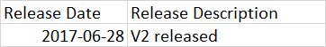

```python
#Create a copy of main dataframe to work on
dfTemp = df.copy()
```

Populate details Day, Month, Weekday, week details for Account Creation Date

```python
%%timeit
dfTemp['yearAccCreate'] = dfTemp['Free Account Created Date'].apply(lambda x: x.strftime('%Y'))
dfTemp['monthAccCreate'] = dfTemp['Free Account Created Date'].apply(lambda x: x.strftime('%#m'))
dfTemp['weekAccCreate'] = dfTemp['Free Account Created Date'].apply(lambda x: x.strftime('%W'))
dfTemp['dayAccCreate'] = dfTemp['Free Account Created Date'].apply(lambda x: x.strftime('%d'))
dfTemp['weekdayAccCreate'] = dfTemp['Free Account Created Date'].apply(lambda x: x.strftime('%w'))
```

```
31.6 ms ± 2.8 ms per loop (mean ± std. dev. of 7 runs, 10 loops each)
```

```python
#Change the datatype to int for easier computions at later stage.
dfTemp = dfTemp.astype({'yearAccCreate': 'int64',
                        'monthAccCreate': 'int64',
                        'weekAccCreate': 'int64',
                        'dayAccCreate': 'int64',
                        'weekdayAccCreate': 'int64'})
```

Populate details Day, Month, Weekday, week details for Account Upgrade Date

```python
%%timeit
dfTemp['yearUpg'] = dfTemp['Upgraded Account Created Date'].apply(lambda x: x.strftime('%Y'))
dfTemp['monthUpg'] = dfTemp['Upgraded Account Created Date'].apply(lambda x: x.strftime('%#m'))
dfTemp['weekUpg'] = dfTemp['Upgraded Account Created Date'].apply(lambda x: x.strftime('%W'))
dfTemp['dayUpg'] = dfTemp['Upgraded Account Created Date'].apply(lambda x: x.strftime('%d'))
dfTemp['weekdayUpg'] = dfTemp['Upgraded Account Created Date'].apply(lambda x: x.strftime('%w'))
```

```
29.8 ms ± 2.16 ms per loop (mean ± std. dev. of 7 runs, 10 loops each)
```

```python
#Change the datatype to int for easier computions at later stage.
dfTemp = dfTemp.astype({'yearUpg': 'int64',
                        'monthUpg': 'int64',
                        'weekUpg': 'int64',
                        'dayUpg': 'int64',
                        'weekdayUpg': 'int64'})
```

Populate details Day, Month, Weekday, week details for Account Cancelled Date

```python
%%timeit
dfTemp['yearUpgCancel'] = dfTemp[dfTemp['Account Status']=='cancelled'
                                ]['Upgraded Account Cancelled Date'].apply(lambda x: x.strftime('%Y'))
dfTemp['monthUpgCancel'] = dfTemp[dfTemp['Account Status']=='cancelled'
                                ]['Upgraded Account Cancelled Date'].apply(lambda x: x.strftime('%#m'))
dfTemp['weekUpgCancel'] = dfTemp[dfTemp['Account Status']=='cancelled'
                                ]['Upgraded Account Cancelled Date'].apply(lambda x: x.strftime('%W'))
dfTemp['dayUpgCancel'] = dfTemp[dfTemp['Account Status']=='cancelled'
                                ]['Upgraded Account Cancelled Date'].apply(lambda x: x.strftime('%d'))
dfTemp['weekdayUpgCancel'] = dfTemp[dfTemp['Account Status']=='cancelled'
                                ]['Upgraded Account Cancelled Date'].apply(lambda x: x.strftime('%w'))
```

```
8.18 ms ± 410 µs per loop (mean ± std. dev. of 7 runs, 100 loops each)
```

```python
#Fill the cancellation dates where the status is 'paying' with 0.
dfTemp.loc[dfTemp['Account Status']=='paying'
          ] = dfTemp.loc[dfTemp['Account Status']=='paying'].fillna(0)
```

```python
#Change the datatype to int for easier computions at later stage.
dfTemp = dfTemp.astype({'yearUpgCancel': 'int64',
                        'monthUpgCancel': 'int64',
                        'weekUpgCancel': 'int64',
                        'dayUpgCancel': 'int64',
                        'weekdayUpgCancel': 'int64'})
```

Find the Day, Month, Year, Weekday details of V2 Release Date

```python
dfReleaseV2 = pd.DataFrame(['2017-06-28'],columns = ['releaseDateV2'])
dfReleaseV2 = dfReleaseV2.astype('datetime64')
dfReleaseV2['year'] = dfReleaseV2['releaseDateV2'].apply(lambda x: x.strftime('%Y'))
dfReleaseV2['month'] = dfReleaseV2['releaseDateV2'].apply(lambda x: x.strftime('%#m'))
dfReleaseV2['week'] = dfReleaseV2['releaseDateV2'].apply(lambda x: x.strftime('%W'))
dfReleaseV2['day'] = dfReleaseV2['releaseDateV2'].apply(lambda x: x.strftime('%d'))
dfReleaseV2['weekday'] = dfReleaseV2['releaseDateV2'].apply(lambda x: x.strftime('%w'))
```

```python
#Change the datatype to int for easier computions at later stage.
dfReleaseV2 = dfReleaseV2.astype({'year': 'int64',
                                  'month': 'int64',
                                  'week': 'int64',
                                  'day': 'int64',
                                  'weekday': 'int64'})
```

```python
dfReleaseV2
```

|  | releaseDateV2 | year | month | week | day | weekday |
| --- | --- | --- | --- | --- | --- | --- |
| 0 | 2017-06-28 | 2017 | 6 | 26 | 28 | 3 |

Computer Customer Account Changes based on Release Day

```python
noOfCustDay = [dfTemp[(dfTemp['Free Account Created Date']=='2017-06-28')]['Customer ID'].nunique(),
              dfTemp[(dfTemp['Upgraded Account Created Date']=='2017-06-28')]['Customer ID'].nunique(),
              dfTemp[(dfTemp['Upgraded Account Cancelled Date']=='2017-06-28')]['Customer ID'].nunique()]

noOfCustDayLabel = ['Joined','Upgraded','Cancellations']
```

Computer Customer Account Changes based on following week

```python
noOfCustWeek = [dfTemp[(dfTemp['yearAccCreate']==dfReleaseV2['year'][0])&
                   (dfTemp['weekAccCreate']==dfReleaseV2['week'][0]+1)
                   ]['Customer ID'].nunique(),
                dfTemp[(dfTemp['yearUpg']==dfReleaseV2['year'][0])&
                   (dfTemp['weekUpg']==dfReleaseV2['week'][0]+1)
                   ]['Customer ID'].nunique(),
                dfTemp[(dfTemp['yearUpgCancel']==dfReleaseV2['year'][0])&
                   (dfTemp['weekUpgCancel']==dfReleaseV2['week'][0]+1)
                   ]['Customer ID'].nunique()
               ]

noOfCustWeekLabel = ['Joined','Upgraded','Cancellations']
```

Computer Customer Account Changes based on following Month

```python
noOfCustMonth = [dfTemp[(dfTemp['yearAccCreate']==dfReleaseV2['year'][0])&
                   (dfTemp['monthAccCreate']==dfReleaseV2['month'][0]+1)
                   ]['Customer ID'].nunique(),
                dfTemp[(dfTemp['yearUpg']==dfReleaseV2['year'][0])&
                   (dfTemp['monthUpg']==dfReleaseV2['month'][0]+1)
                   ]['Customer ID'].nunique(),
                dfTemp[(dfTemp['yearUpgCancel']==dfReleaseV2['year'][0])&
                   (dfTemp['monthUpgCancel']==dfReleaseV2['month'][0]+1)
                   ]['Customer ID'].nunique()
               ]

noOfCustMonthLabel = ['Joined','Upgraded','Cancellations']
```

```python
noOfCustMonth3 = [dfTemp[(dfTemp['yearAccCreate']==dfReleaseV2['year'][0])&
                   (dfTemp['monthAccCreate'].between(dfReleaseV2['month'][0]+1,dfReleaseV2['month'][0]+2))
                   ]['Customer ID'].nunique(),
                dfTemp[(dfTemp['yearUpg']==dfReleaseV2['year'][0])&
                   (dfTemp['monthUpg'].between(dfReleaseV2['month'][0]+1,dfReleaseV2['month'][0]+2))
                   ]['Customer ID'].nunique(),
                dfTemp[(dfTemp['yearUpgCancel']==dfReleaseV2['year'][0])&
                   (dfTemp['monthUpgCancel'].between(dfReleaseV2['month'][0]+1,dfReleaseV2['month'][0]+2))
                   ]['Customer ID'].nunique()
               ]

noOfCustMonth3Label = ['Joined','Upgraded','Cancellations']
```

Create visualizations for V2 Release and customer account changes

```python
#Create figure with subplots
fig = make_subplots(rows=2, cols=2,
                    vertical_spacing=0.3,
                    subplot_titles=("<b>On Release Day</b>",
                                    "<b>After 1 Week</b>",
                                    "<b>After 1 Month</b>",
                                    "<b>Within next 3 months</b>"))

#define the color scheme for bars
colors = ['rgb(51, 51, 204)','rgb(0, 153, 0)','rgb(179, 0, 0)']

#On Release Day
fig.add_trace(go.Bar(name='On Release Day', x=noOfCustDayLabel, y=noOfCustDay,
                     text=noOfCustDay, textposition="outside",
                       hovertemplate = "%{x}: %{y} </br>",
                     marker=dict(
                                color=colors,
                                line=dict(color='black', width=2)
                                )), row=1, col=1
             )

#After one Week of release
fig.add_trace(go.Bar(name='After 1 Week', x=noOfCustWeekLabel, y=noOfCustWeek,
                     text=noOfCustWeek, textposition="outside",
                       hovertemplate = "%{x}: %{y} </br>",
                     marker=dict(
                                color=colors,
                                line=dict(color='black', width=2)
                                )), row=1, col=2
             )
#After one month of release
fig.add_trace(go.Bar(name='After 1 Month', x=noOfCustWeekLabel, y=noOfCustMonth,
                     text=noOfCustMonth, textposition="inside",
                       hovertemplate = "%{x}: %{y} </br>",
                     marker=dict(
                                color=colors,
                                line=dict(color='black', width=2)
                                )), row=2, col=1
             )

#Within next three months of release
fig.add_trace(go.Bar(name='Within next 3 months', x=noOfCustWeekLabel, y=noOfCustMonth3,
                     text=noOfCustMonth3, textposition="inside",
                       hovertemplate = "%{x}: %{y} </br>",
                     marker=dict(
                                color=colors,
                                line=dict(color='black', width=2)
                                )), row=2, col=2
             )


#Cosmetic changes to figure
fig.update_layout(
                    title={'text':"<b>Impact of V2 release on New Customers, Upgrades and Cancellations</b>",
                            'x':0.1,'xanchor':'left','font':dict(size=20,color='black')
                          }
                 )

# Update xaxis properties
fig.update_xaxes(title_text="Impact on Customer",  titlefont_size=14, tickfont_size=12, tickmode='linear', row=1, col=1)
fig.update_xaxes(title_text="Impact on Customer",  titlefont_size=14, tickfont_size=12, tickmode='linear',row=1, col=2)
fig.update_xaxes(title_text="Impact on Customer",  titlefont_size=14, tickfont_size=12, tickmode='linear', row=2, col=1)
fig.update_xaxes(title_text="Impact on Customer",  titlefont_size=14, tickfont_size=12, tickmode='linear',row=2, col=2)

# Update yaxis properties
fig.update_yaxes(title_text="Number of Customers", titlefont_size=14, tickfont_size=12, row=1, col=1)
fig.update_yaxes(title_text="Number of Customers", titlefont_size=14, tickfont_size=12, row=2, col=1)

# Update figure size
fig.update_layout(autosize=True, height=600, showlegend=False)

fig.show()
```

[interactive chart not shown]

**Note:**

**Conclusion:** V2 did not have a compelling effect on customers.

### Analysis for V3 Release and Product Pricing Changed

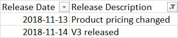

Find the Day, Month, Year, Weekday details of V3 Release Date

```python
dfReleaseV3 = pd.DataFrame(['2018-11-14'],columns = ['releaseDateV3'])
dfReleaseV3 = dfReleaseV3.astype('datetime64')
dfReleaseV3['year'] = dfReleaseV3['releaseDateV3'].apply(lambda x: x.strftime('%Y'))
dfReleaseV3['month'] = dfReleaseV3['releaseDateV3'].apply(lambda x: x.strftime('%#m'))
dfReleaseV3['week'] = dfReleaseV3['releaseDateV3'].apply(lambda x: x.strftime('%W'))
dfReleaseV3['day'] = dfReleaseV3['releaseDateV3'].apply(lambda x: x.strftime('%d'))
dfReleaseV3['weekday'] = dfReleaseV3['releaseDateV3'].apply(lambda x: x.strftime('%w'))
```

```python
#Change the datatype to int for easier computions at later stage.
dfReleaseV3 = dfReleaseV3.astype({'year': 'int64',
                                  'month': 'int64',
                                  'week': 'int64',
                                  'day': 'int64',
                                  'weekday': 'int64'})
```

```python
dfReleaseV3
```

|  | releaseDateV3 | year | month | week | day | weekday |
| --- | --- | --- | --- | --- | --- | --- |
| 0 | 2018-11-14 | 2018 | 11 | 46 | 14 | 3 |

Computer Customer Account Changes based on Release Day

```python
noOfCustDay = [dfTemp[(dfTemp['Free Account Created Date']=='2018-11-14')]['Customer ID'].nunique(),
              dfTemp[(dfTemp['Upgraded Account Created Date']=='2018-11-14')]['Customer ID'].nunique(),
              dfTemp[(dfTemp['Upgraded Account Cancelled Date']=='2018-11-14')]['Customer ID'].nunique()]

noOfCustDayLabel = ['Joined','Upgraded','Cancellations']
```

Computer Customer Account Changes based on following week

```python
noOfCustWeek = [dfTemp[(dfTemp['yearAccCreate']==dfReleaseV3['year'][0])&
                   (dfTemp['weekAccCreate']==dfReleaseV3['week'][0]+1)
                   ]['Customer ID'].nunique(),
                dfTemp[(dfTemp['yearUpg']==dfReleaseV3['year'][0])&
                   (dfTemp['weekUpg']==dfReleaseV3['week'][0]+1)
                   ]['Customer ID'].nunique(),
                dfTemp[(dfTemp['yearUpgCancel']==dfReleaseV3['year'][0])&
                   (dfTemp['weekUpgCancel']==dfReleaseV3['week'][0]+1)
                   ]['Customer ID'].nunique()
               ]

noOfCustWeekLabel = ['Joined','Upgraded','Cancellations']
```

Computer Customer Account Changes based on following Month

```python
noOfCustMonth = [dfTemp[(dfTemp['yearAccCreate']==dfReleaseV3['year'][0])&
                   (dfTemp['monthAccCreate']==dfReleaseV3['month'][0]+1)
                   ]['Customer ID'].nunique(),
                dfTemp[(dfTemp['yearUpg']==dfReleaseV3['year'][0])&
                   (dfTemp['monthUpg']==dfReleaseV3['month'][0]+1)
                   ]['Customer ID'].nunique(),
                dfTemp[(dfTemp['yearUpgCancel']==dfReleaseV3['year'][0])&
                   (dfTemp['monthUpgCancel']==dfReleaseV3['month'][0]+1)
                   ]['Customer ID'].nunique()
               ]

noOfCustMonthLabel = ['Joined','Upgraded','Cancellations']
```

Computer Customer Account Changes based on next three months

```python
noOfCustMonth3 = [dfTemp[((dfTemp['yearAccCreate']==dfReleaseV3['year'][0]
                          )&(dfTemp['monthAccCreate']==dfReleaseV3['month'][0]+1)
                         )|((dfTemp['yearAccCreate']==dfReleaseV3['year'][0]+1
                            )&(dfTemp['monthAccCreate'].between(1,2)))
                        ]['Customer ID'].nunique(),
                dfTemp[((dfTemp['yearUpg']==dfReleaseV3['year'][0]
                          )&(dfTemp['monthUpg']==dfReleaseV3['month'][0]+1)
                         )|((dfTemp['yearUpg']==dfReleaseV3['year'][0]+1
                            )&(dfTemp['monthUpg'].between(1,2)))
                        ]['Customer ID'].nunique(),
                dfTemp[((dfTemp['yearUpgCancel']==dfReleaseV3['year'][0]
                          )&(dfTemp['monthUpgCancel']==dfReleaseV3['month'][0]+1)
                         )|((dfTemp['yearUpgCancel']==dfReleaseV3['year'][0]+1
                            )&(dfTemp['monthUpgCancel'].between(1,2)))
                        ]['Customer ID'].nunique()
               ]

noOfCustMonth3Label = ['Joined','Upgraded','Cancellations']
```

Create visualizations for V3 Release and customer account changes

```python
#Create figure with subplots
fig = make_subplots(rows=2, cols=2,
                    vertical_spacing=0.2,
                    subplot_titles=("<b><br>On Release Day</b>",
                                    "<b>After 1 Week</b>",
                                    "<b>After 1 Month</b>",
                                    "<b>Within next 3 months</b>"))

#define the color scheme for bars
colors = ['rgb(51, 51, 204)','rgb(0, 153, 0)','rgb(179, 0, 0)']

#On Release Day
fig.add_trace(go.Bar(name='On Release Day', x=noOfCustDayLabel, y=noOfCustDay,
                     text=noOfCustDay, textposition="inside",
                       hovertemplate = "%{x}: %{y} </br>",
                     marker=dict(
                                color=colors,
                                line=dict(color='black', width=2)
                                )), row=1, col=1
             )

#After one Week of release
fig.add_trace(go.Bar(name='After 1 Week', x=noOfCustWeekLabel, y=noOfCustWeek,
                     text=noOfCustWeek, textposition="inside",
                       hovertemplate = "%{x}: %{y} </br>",
                     marker=dict(
                                color=colors,
                                line=dict(color='black', width=2)
                                )), row=1, col=2
             )
#After one month of release
fig.add_trace(go.Bar(name='After 1 Month', x=noOfCustWeekLabel, y=noOfCustMonth,
                     text=noOfCustMonth, textposition="inside",
                       hovertemplate = "%{x}: %{y} </br>",
                     marker=dict(
                                color=colors,
                                line=dict(color='black', width=2)
                                )), row=2, col=1
             )

#Within next three months of release
fig.add_trace(go.Bar(name='Within next 3 months', x=noOfCustWeekLabel, y=noOfCustMonth3,
                     text=noOfCustMonth3, textposition="inside",
                       hovertemplate = "%{x}: %{y} </br>",
                     marker=dict(
                                color=colors,
                                line=dict(color='black', width=2)
                                )), row=2, col=2
             )


#Cosmetic changes to figure
fig.update_layout(
                    title={'text':
                           "<b>Impact of V3 release/Product Pricing change on New Customers, Upgrades and Cancellations</b>",
                            'x':0.05,'xanchor':'left','font':dict(size=17,color='black')
                          }
                 )

# Update xaxis properties
fig.update_xaxes(title_text="Impact on Customer",  titlefont_size=14, tickfont_size=12, tickmode='linear', row=1, col=1)
fig.update_xaxes(title_text="Impact on Customer",  titlefont_size=14, tickfont_size=12, tickmode='linear',row=1, col=2)
fig.update_xaxes(title_text="Impact on Customer",  titlefont_size=14, tickfont_size=12, tickmode='linear', row=2, col=1)
fig.update_xaxes(title_text="Impact on Customer",  titlefont_size=14, tickfont_size=12, tickmode='linear',row=2, col=2)

# Update yaxis properties
fig.update_yaxes(title_text="Number of Customers", titlefont_size=14, tickfont_size=12, row=1, col=1)
fig.update_yaxes(title_text="Number of Customers", titlefont_size=14, tickfont_size=12, row=2, col=1)

# Update figure size
fig.update_layout(autosize=True, height=600, showlegend=False)

fig.show()
```

[interactive chart not shown]

**Note:**

1. V3 release and Product price change had a direct impact.
2. Right from the day of V3 release, new customers have started joining and upgrading the accounts.
3. Within next 3 months of V3 release, 293 customers joined and 270 upgraded their accounts. However, 50 customers cancelled the upgraded account so it needs further investigation.

**Conclusion:** V3 release and Price change had high positive impact on customers.

## Yearly analysis of Customer joined, Accounts upgraded and Cancelled

```python
print("The dataset contains 'Free Account Created Date' data only for:", dfTemp['Free Account Created Date'
                                                                               ].dt.year.nunique(), "year(s) i.e."
     ,*dfTemp['Free Account Created Date'].dt.year.unique())
```

```
The dataset contains 'Free Account Created Date' data only for: 3 year(s) i.e. 2017 2018 2019
```

```python
#Process the data of China based grouped by date
yearCreate2017 = dfTemp[dfTemp['yearAccCreate']==2017].groupby(['monthAccCreate'])['Customer ID'].nunique()
yearCreate2018 = dfTemp[dfTemp['yearAccCreate']==2018].groupby(['monthAccCreate'])['Customer ID'].nunique()
yearCreate2019 = dfTemp[dfTemp['yearAccCreate']==2019].groupby(['monthAccCreate'])['Customer ID'].nunique()
yearUpg2017 = dfTemp[dfTemp['yearUpg']==2017].groupby(['monthUpg'])['Customer ID'].nunique()
yearUpg2018 = dfTemp[dfTemp['yearUpg']==2018].groupby(['monthUpg'])['Customer ID'].nunique()
yearUpg2019 = dfTemp[dfTemp['yearUpg']==2019].groupby(['monthUpg'])['Customer ID'].nunique()
yearCancel2017 = dfTemp[dfTemp['yearUpgCancel']==2017].groupby(['monthUpgCancel'])['Customer ID'].nunique()
yearCancel2018 = dfTemp[dfTemp['yearUpgCancel']==2018].groupby(['monthUpgCancel'])['Customer ID'].nunique()
yearCancel2019 = dfTemp[dfTemp['yearUpgCancel']==2019].groupby(['monthUpgCancel'])['Customer ID'].nunique()

#define the color scheme for bars
colors = ['rgb(51, 51, 204)','rgb(0, 153, 0)','rgb(179, 0, 0)']

#Defining the labels for x-axis
x_labels = ['Jan','Feb','Mar','Apr','May','Jun', 'Jul', 'Aug', 'Sep','Oct','Nov','Dec']

#Create figure with subplots
fig = make_subplots(rows=2, cols=2,  vertical_spacing=0.1, specs=[[{}, {}], [{"colspan": 2}, None]],
                    row_heights = [0.5,0.5],
                    subplot_titles=("Year: 2017", "Year: 2018", "Year: 2019"))

#2017
#New Customers
fig.add_trace(go.Scatter(name='Year: 2017, New Customers',
                        y=yearCreate2017.values,
                        x=x_labels,
                        text=yearCreate2017.values,
                        textposition="top center",
                        mode='lines+markers',
                        hovertemplate = "%{x}: %{y} </br>",
                        marker=dict(color=colors[0], size=10, line=dict(color='rgb(55, 83, 109)', width=0)),
                        line=dict(color='rgb(55, 83, 109)', width=2), showlegend=False,
                        ), row=1, col=1
             )

#Upgraded Customers
fig.add_trace(go.Scatter(name='Year: 2017, New Upgrades',
                        y=yearUpg2017.values,
                        x=x_labels,
                        text=yearUpg2017.values,
                        textposition="top center",
                        mode='lines+markers',
                        hovertemplate = "%{x}: %{y} </br>",
                        marker=dict(color=colors[1], size=10, line=dict(color='rgb(55, 83, 109)', width=0)),
                        line=dict(color='rgb(55, 83, 109)', width=2), showlegend=False,
                        ), row=1, col=1
             )

#Cancellations
fig.add_trace(go.Scatter(name='Year: 2017, New Cancellations',
                        y=yearCancel2017.values,
                        x=x_labels,
                        text=yearCancel2017.values,
                        textposition="top center",
                        mode='lines+markers',
                        hovertemplate = "%{x}: %{y} </br>",
                        marker=dict(color=colors[2], size=10, line=dict(color='rgb(55, 83, 109)', width=0)),
                        line=dict(color='rgb(55, 83, 109)', width=2), showlegend=False,
                        ), row=1, col=1
             )



#2018
#New Customers
fig.add_trace(go.Scatter(name='New Customers',
                        y=yearCreate2018.values,
                        x=x_labels,
                        text=yearCreate2018.values,
                        textposition="top center",
                        mode='lines+markers',
                        hovertemplate = "%{x}: %{y} </br>",
                        marker=dict(color=colors[0], size=10, line=dict(color='rgb(55, 83, 109)', width=0)),
                        line=dict(color='rgb(55, 83, 109)', width=2)
                        ), row=1, col=2
             )

#Upgraded Customers
fig.add_trace(go.Scatter(name='New Upgrades',
                        y=yearUpg2018.values,
                        x=x_labels,
                        text=yearUpg2018.values,
                        textposition="top center",
                        mode='lines+markers',
                        hovertemplate = "%{x}: %{y} </br>",
                        marker=dict(color=colors[1], size=10, line=dict(color='rgb(55, 83, 109)', width=0)),
                        line=dict(color='rgb(55, 83, 109)', width=2)
                        ), row=1, col=2
             )

#Cancellations
fig.add_trace(go.Scatter(name='New Cancellations',
                        y=yearCancel2018.values,
                        x=x_labels,
                        text=yearCancel2018.values,
                        textposition="top center",
                        mode='lines+markers',
                        hovertemplate = "%{x}: %{y} </br>",
                        marker=dict(color=colors[2], size=10, line=dict(color='rgb(55, 83, 109)', width=0)),
                        line=dict(color='rgb(55, 83, 109)', width=2)
                        ), row=1, col=2
             )

#2019
#New Customers
fig.add_trace(go.Scatter(name='Year: 2019, New Customers',
                        y=yearCreate2019.values,
                        x=x_labels,
                        text=yearCreate2019.values,
                        textposition="top center",
                        mode='lines+markers',
                        hovertemplate = "%{x}: %{y} </br>",
                        marker=dict(color=colors[0], size=10, line=dict(color='rgb(55, 83, 109)', width=0)),
                        line=dict(color='rgb(55, 83, 109)', width=2), showlegend=False,
                        ), row=2, col=1
             )

#Upgraded Customers
fig.add_trace(go.Scatter(name='Year: 2019, New Upgrades',
                        y=yearUpg2019.values,
                        x=x_labels,
                        text=yearUpg2019.values,
                        textposition="top center",
                        mode='lines+markers',
                        hovertemplate = "%{x}: %{y} </br>",
                        marker=dict(color=colors[1], size=10, line=dict(color='rgb(55, 83, 109)', width=0)),
                        line=dict(color='rgb(55, 83, 109)', width=2), showlegend=False,
                        ), row=2, col=1
             )

#Cancellations
fig.add_trace(go.Scatter(name='Year: 2019, New Cancellations',
                        y=yearCancel2019.values,
                        x=x_labels,
                        text=yearCancel2019.values,
                        textposition="top center",
                        mode='lines+markers',
                        hovertemplate = "%{x}: %{y} </br>",
                        marker=dict(color=colors[2], size=10, line=dict(color='rgb(55, 83, 109)', width=0)),
                        line=dict(color='rgb(55, 83, 109)', width=2), showlegend=False,
                        ), row=2, col=1
             )



#Cosmetic changes to figure
fig.update_layout(
                    title={'text':'<b>Yearly analysis of New customers joined, Accounts Upgraded and Cancelled</b>',
                            'x':0.1,'xanchor':'left','font':dict(size=20,color='black')
                          }
                 )

fig.update_layout(legend_orientation="h",
                  legend=dict(
                                x=0.25,
                                y=-0.05,
                                bgcolor='rgba(255, 255, 255, 0)',
                                bordercolor='red'
                            )
                 )

# Update yaxis properties
fig.update_yaxes(title_text="Number of Customers", titlefont_size=16, tickfont_size=15, row=1, col=1)
fig.update_yaxes(title_text="Number of Customers", titlefont_size=16, tickfont_size=15, row=2, col=1)

# Update figure size
fig.update_layout(autosize=True, height=700)

fig.show()
```

[interactive chart not shown]

**Note:**

1. **Year 2017:** This year is the starting year in the dataset. Probably, the establishment of the product. A good account creation rate was observed with extremely low account upgrade rate. No cancellations.
2. **Year 2018:** Received high attention from customers. An increasing rate of new customer join and account upgrades can be observed. ATTENTION: Account upgrades have been cancelled continuously by each month.
3. **Year 2019:** Received high attention from customers. An increasing rate of new customer join and account upgrades can be observed. Account upgrade cancellation rate have been reduced enormously this year.

## Analsyis for busiest day of a week based on New Account Create Date, Last Seen Date, Account Upgrade Date, and Account Cancelled Date

```python
%%timeit
dfTemp['yearLastSeen'] = dfTemp['Last Seen'].apply(lambda x: x.strftime('%Y'))
dfTemp['monthLastSeen'] = dfTemp['Last Seen'].apply(lambda x: x.strftime('%#m'))
dfTemp['weekLastSeen'] = dfTemp['Last Seen'].apply(lambda x: x.strftime('%W'))
dfTemp['dayLastSeen'] = dfTemp['Last Seen'].apply(lambda x: x.strftime('%d'))
dfTemp['weekdayLastSeen'] = dfTemp['Last Seen'].apply(lambda x: x.strftime('%w'))
dfTemp['timeLastSeen'] = dfTemp['Last Seen'].apply(lambda x: x.strftime('%H'))
```

```
41.8 ms ± 3.72 ms per loop (mean ± std. dev. of 7 runs, 10 loops each)
```

```python
#Change the datatype to int for easier computions at later stage.
dfTemp = dfTemp.astype({'yearLastSeen': 'int64',
                        'monthLastSeen': 'int64',
                        'weekLastSeen': 'int64',
                        'dayLastSeen': 'int64',
                        'weekdayLastSeen': 'int64',
                        'timeLastSeen': 'int64'})
```

```python
#Process the data for Weekday's
AcCreateWeekday = dfTemp.groupby(['weekdayAccCreate'])['Customer ID'].nunique()
lastSeenWeekday = dfTemp.groupby(['weekdayLastSeen'])['Customer ID'].nunique()
UpgWeekday = dfTemp.groupby(['weekdayUpg'])['Customer ID'].nunique()
CancelWeekday = dfTemp.groupby(['weekdayUpgCancel'])['Customer ID'].nunique()
```

```python
#Create figure with subplots
fig = make_subplots(rows=2, cols=2,
                    vertical_spacing=0.15,
                    subplot_titles=("<b><br>Customers Last Seen</b>",
                                    "<b>Accounts Created</b>",
                                    "<b>Accounts Upgraded</b>",
                                    "<b>Upgraded Accounts Cancelled</b>"))

#labels for x-axis
x_labels = ['Sun', 'Mon', 'Tue', 'Wed', 'Thu', 'Fri','Sat']

#define the color scheme for bars
colors = ['rgb(55, 83, 109)','rgb(51, 51, 204)','rgb(0, 153, 0)','rgb(179, 0, 0)']


AcCreateWeekday = dfTemp.groupby(['weekdayAccCreate'])['Customer ID'].nunique()
lastSeenWeekday = dfTemp.groupby(['weekdayLastSeen'])['Customer ID'].nunique()
UpgWeekday = dfTemp.groupby(['weekdayUpg'])['Customer ID'].nunique()
CancelWeekday = dfTemp.groupby(['weekdayUpgCancel'])['Customer ID'].nunique()


#After one Week of release
fig.add_trace(go.Bar(name='Last Seen', x=x_labels, y=lastSeenWeekday,
                     text=lastSeenWeekday, textposition="inside",
                     hovertemplate = "%{x}: %{y} </br>",
                     marker=dict(
                                color=colors[0],
                                line=dict(color='black', width=2)
                                )), row=1, col=1
             )

#On Release Day
fig.add_trace(go.Bar(name='Accounts Created', x=x_labels, y=AcCreateWeekday,
                     text=AcCreateWeekday, textposition="inside",
                     hovertemplate = "%{x}: %{y} </br>",
                     marker=dict(
                                color=colors[1],
                                line=dict(color='black', width=2)
                                )), row=1, col=2
             )

#After one month of release
fig.add_trace(go.Bar(name='Accounts Upgraded', x=x_labels, y=UpgWeekday,
                     text=UpgWeekday, textposition="inside",
                     hovertemplate = "%{x}: %{y} </br>",
                     marker=dict(
                                color=colors[2],
                                line=dict(color='black', width=2)
                                )), row=2, col=1
             )

#Within next three months of release
fig.add_trace(go.Bar(name='Upgraded Accounts Cancelled', x=x_labels, y=CancelWeekday,
                     text=CancelWeekday, textposition="outside",
                     hovertemplate = "%{x}: %{y} </br>",
                     marker=dict(
                                color=colors[3],
                                line=dict(color='black', width=2)
                                )), row=2, col=2
             )

#Customize the legend
fig.update_layout(legend_orientation="h",
                  legend=dict(
                                x=0.15,
                                y=-0.10,
                                bgcolor='rgba(255, 255, 255, 0)',
                                bordercolor='red'
                            )
                 )

#Cosmetic changes to figure
fig.update_layout(
                    title={'text':
                           "<b>Busiest days of a week</b>",
                            'x':0.35,'xanchor':'left','font':dict(size=20,color='black')
                          }
                 )

# Update yaxis properties
fig.update_yaxes(title_text="Number of Customers", titlefont_size=14, tickfont_size=12, row=1, col=1)
fig.update_yaxes(title_text="Number of Customers", titlefont_size=14, tickfont_size=12, row=2, col=1)

# Update figure size
fig.update_layout(autosize=True, height=600, showlegend=True)

fig.show()
```

[interactive chart not shown]

**Note:**

```
1. Customer are active mostly on Friday and Weekend. Sunday can be targeted to launch a product to make the most noise.
2. Least accounts are created on Wednesday and Thursday.
3. Most accounts are upgraded on Saturday and Monday.
4. Most of the account are cancelled on Sunday.
```